hyperlink to your webpage at github.io https://stellacwxxvi.github.io/

# "The Overlooked Statistic: Underdiagnosis Among Minorities"

## Introduction

### Background

At the core of this project is a deeply personal motivation. Having been both mentored by and taught individuals with learning disabilities, I have long been interested in how these conditions are recognized and diagnosed. Most of my schooling occurred in predominantly white institutions, where the majority of diagnosed individuals I encountered were white, male, and from middle- to upper-income families. While this observation stems from personal experience, it sparked a broader curiosity I now wish to explore through data science.

For this project, I will analyze public health data related to the diagnosis of learning disabilities in young females. My goal is to investigate whether there are significant differences in diagnosis rates between males and females while examining the influence of socioeconomic status and poverty levels. By connecting my passion for data science with a topic related to my identity and lived experience, I hope to contribute meaningful insights to a conversation often limited by biased systems and unequal representation. This data is fascinating, personally relevant, and necessary to study if we aim to understand—and ultimately address—the disparities in educational and medical diagnoses.

### Data Source

I have chosen to utilize the dataset from the Centers for Disease Control and Prevention (CDC) / National Center for Health Statistics, specifically the National Health Interview Survey covering the years 2019–2023. This dataset is available on the CDC’s official website and serves as a public resource intended to support CDC staff, public health departments, researchers, and other stakeholders. The CDC aims for these datasets to aid in "public health research, decision-making, priority setting, program evaluation, and resource allocation."

The National Health Interview Survey (NHIS) is conducted annually and gathers health-related data from U.S. households through voluntary participation. While the data is nationally representative, it is not exhaustive since it relies on individuals opting into the survey. Responses are categorized across various demographic variables, enabling researchers to analyze the data by race, sex, and poverty level, among other factors. For this project, I downloaded subsets of data that report positive diagnoses of Attention Deficit Hyperactivity Disorder (ADHD) and learning disabilities, specifically organized by sex, race, and poverty level.

Key survey questions included: “Has a doctor or other health professional ever told you that [child's name] had attention deficit hyperactivity disorder (ADHD) or attention deficit disorder (ADD)?” and “Has a representative from a school or a health professional ever told you that [child's name] had a learning disability?”

The data reflects the percentage of "Yes" responses out of all possible answers, which include “Yes,” “No,” “Refused,” and “Don’t know.” For this project, I downloaded the data in six parts: ADHD diagnoses segmented by sex, race, and poverty level, as well as learning disability diagnoses organized in the same manner.

There are several limitations to this dataset. First, the survey is voluntary, which may result in underrepresentation of individuals with ADHD or learning disabilities. Additionally, because the survey relies on self-reporting or parental reporting, there may be discrepancies in how learning disabilities are defined or understood. Some respondents may conflating ADHD with learning disabilities, potentially skewing the data. Furthermore, this dataset focuses on children and does not include information on adults with ADHD or learning disabilities, as those questions were not asked in the survey.

Despite these limitations, this dataset offers a robust sample size and provides valuable insights for analyzing disparities in diagnosis across different populations. The official documentation for the National Health Interview Survey dataset can be accessed here:https://www.cdc.gov/nchs/nhis/about/index.html#cdc_survey_profile_collected-whats-collected.

More detailed information about the survey structure and questionnaire content can be found in this NHIS Sample Child Questionnaire PDF: https://www.cdc.gov/nchs/data/nhis/Sample-Child-Questionnaire.pdf.

#### Question

This study aims to determine whether positive diagnosis rates for ADHD and learning disabilities are influenced by race, gender, and socioeconomic status.

#### Hypothesis

I hypothesize that young white males from higher-income brackets will have a higher prevalence of positive diagnoses compared to their counterparts. This may be due to several factors. Individuals from wealthier backgrounds often have greater access to healthcare resources and testing. Additionally, socialization patterns may play a role. Girls are typically socilized to be more compliant and may hide their struggles more effectively, while boys are often discouraged from showing vulnerability, which can result in more noticeable behavior. Lastly, racial and gender biases may influence who is referred for evaluation and diagnosis.

## Data: Extraction, Transform, and Load

This dataset was extracted from the CDC's official GitHub repository, which provides access to publicly available data from the National Health Interview Survey conducted between 2019 and 2023. After reviewing the associated use policies, users can download data files that are relevant to their research interests. The platform allows for a custom selection of variables, including demographic filters such as race, sex, age, and poverty level. For this project, I selected and downloaded specific subsets of data related to ADHD and learning disabilities.

#### Load

For this project, I unitlized Python 3, pandas, maplotlib, and more. Our first code cell will be importing the necessary libraries.

```python
%cd /content
!git clone https://github.com/HHS-NHIS/SHS_TABLES_CHILDREN.git

%cd /content/SHS_TABLES_CHILDREN/www

import json
import pandas as pd
import numpy as np
import matplotlib.pyplot as plt
```

```
/content
Cloning into 'SHS_TABLES_CHILDREN'...
remote: Enumerating objects: 1893, done.
remote: Counting objects: 100% (1772/1772), done.
remote: Compressing objects: 100% (400/400), done.
remote: Total 1893 (delta 1601), reused 1540 (delta 1372), pack-reused 121 (from 1)
Receiving objects: 100% (1893/1893), 13.02 MiB | 9.50 MiB/s, done.
Resolving deltas: 100% (1628/1628), done.
/content/SHS_TABLES_CHILDREN/www
```

```python
file_path = "EVER_ADHD__ind__poverty__.json"

with open(file_path, "r") as f:
    json_data = json.load(f)

# Extract column names and data
columns = json_data["classes"]  # Column names
data = json_data["data"]  # Actual data

# Create DataFrame
ADHD_pov_df = pd.DataFrame(data, columns=columns)

# Display DataFrame
from IPython.display import display
display(ADHD_pov_df)
```

|  | Year | row_var | rowLevels | rowLevNum | selected | stat_group | col_group | new_caption | new_caption2 | Less than 100% FPL__povertyA__EVER_ADHD__coef | Less than 100% FPL__povertyA__EVER_ADHD__se | 100% to less than 200% FPL__povertyB__EVER_ADHD__coef | 100% to less than 200% FPL__povertyB__EVER_ADHD__se | 200% and greater FPL__povertyC__EVER_ADHD__coef | 200% and greater FPL__povertyC__EVER_ADHD__se | subLevels |
| --- | --- | --- | --- | --- | --- | --- | --- | --- | --- | --- | --- | --- | --- | --- | --- | --- |
| 0 | 2019 | ind | 2019 | indA | 0 | Health status | Socio-economic status |  | Based on the question "Has a doctor or other h... | 10.9 | 8.8 ,13.3 | 9.3 | 7.8 ,11.0 | 7.9 | 7.1 ,8.9 |  |
| 1 | 2020 | ind | 2020 | indA | 0 | Health status | Socio-economic status |  | Based on the question "Has a doctor or other h... | 14.4 | 10.7, 18.7 | 11.9 | 9.6, 14.6 | 8.6 | 7.5, 9.8 |  |
| 2 | 2021 | ind | 2021 | indA | 0 | Health status | Socio-economic status |  | Based on the question "Has a doctor or other h... | 12.3 | 9.8, 15.1 | 10.3 | 8.6, 12.2 | 8.6 | 7.7, 9.5 |  |
| 3 | 2022 | ind | 2022 | indA | 0 | Health status | Socio-economic status |  | Based on the question "Has a doctor or other h... | 12.4 | 9.8, 15.4 | 9.8 | 8.0, 11.8 | 9.8 | 8.8, 10.8 |  |
| 4 | 2023 | ind | 2023 | indA | 0 | Health status | Socio-economic status |  | Based on the question "Has a doctor or other h... | 12.2 | 9.7, 15.1 | 11.7 | 9.9, 13.8 | 12.0 | 10.9, 13.2 |  |

Now, I will drop unneeded columns.

```python
ADHD_pov_df = ADHD_pov_df.drop(columns=["row_var", "rowLevels", "rowLevNum",	"selected",	"stat_group",	"col_group", "new_caption",	"new_caption2", "subLevels"], errors='ignore')

display(ADHD_pov_df)
```

|  | Year | Less than 100% FPL__povertyA__EVER_ADHD__coef | Less than 100% FPL__povertyA__EVER_ADHD__se | 100% to less than 200% FPL__povertyB__EVER_ADHD__coef | 100% to less than 200% FPL__povertyB__EVER_ADHD__se | 200% and greater FPL__povertyC__EVER_ADHD__coef | 200% and greater FPL__povertyC__EVER_ADHD__se |
| --- | --- | --- | --- | --- | --- | --- | --- |
| 0 | 2019 | 10.9 | 8.8 ,13.3 | 9.3 | 7.8 ,11.0 | 7.9 | 7.1 ,8.9 |
| 1 | 2020 | 14.4 | 10.7, 18.7 | 11.9 | 9.6, 14.6 | 8.6 | 7.5, 9.8 |
| 2 | 2021 | 12.3 | 9.8, 15.1 | 10.3 | 8.6, 12.2 | 8.6 | 7.7, 9.5 |
| 3 | 2022 | 12.4 | 9.8, 15.4 | 9.8 | 8.0, 11.8 | 9.8 | 8.8, 10.8 |
| 4 | 2023 | 12.2 | 9.7, 15.1 | 11.7 | 9.9, 13.8 | 12.0 | 10.9, 13.2 |

#### Rename Columns

To fully understand the data in this section, a couple of definitions need to be established.

**FPL**: Federal Poverty Level

**Lower Income**: Less than 100% of the FPL

**Moderate Income**: 100% to less than 200% of the FPL

**Higher Income**: 200% and more significant than the FPL

For each income level, there are two sections: one detailing the prevalence of positive diagnoses (responses of "yes" to the relevant question) and the other providing the confidence interval for the given prevalence. A confidence interval (CI) is a range of values used to estimate the actual value.

For example, the estimated prevalence of positive diagnoses in the Low-Income group for 2019 is 10.9%. However, the true prevalence could lie between 8.8% and 13.3%.

```python
ADHD_pov_df = ADHD_pov_df.rename(columns={
    "Less than 100% FPL__povertyA__EVER_ADHD__coef": "Low Income Group Prevalence",
    "Less than 100% FPL__povertyA__EVER_ADHD__se": "Low Income Group CI",
    "100% to less than 200% FPL__povertyB__EVER_ADHD__coef": "Moderate Income Group Prevalence",
    "100% to less than 200% FPL__povertyB__EVER_ADHD__se": "Moderate Income Group CI",
    "200% and greater FPL__povertyC__EVER_ADHD__coef": "Higher Income Group Prevalence",
    "200% and greater FPL__povertyC__EVER_ADHD__se": "Higher Income Group CI"
})

display(ADHD_pov_df)
```

|  | Year | Low Income Group Prevalence | Low Income Group CI | Moderate Income Group Prevalence | Moderate Income Group CI | Higher Income Group Prevalence | Higher Income Group CI |
| --- | --- | --- | --- | --- | --- | --- | --- |
| 0 | 2019 | 10.9 | 8.8 ,13.3 | 9.3 | 7.8 ,11.0 | 7.9 | 7.1 ,8.9 |
| 1 | 2020 | 14.4 | 10.7, 18.7 | 11.9 | 9.6, 14.6 | 8.6 | 7.5, 9.8 |
| 2 | 2021 | 12.3 | 9.8, 15.1 | 10.3 | 8.6, 12.2 | 8.6 | 7.7, 9.5 |
| 3 | 2022 | 12.4 | 9.8, 15.4 | 9.8 | 8.0, 11.8 | 9.8 | 8.8, 10.8 |
| 4 | 2023 | 12.2 | 9.7, 15.1 | 11.7 | 9.9, 13.8 | 12.0 | 10.9, 13.2 |

Check dtypes

```python
print(ADHD_pov_df.dtypes)
```

```
Year                                object
Low Income Group Prevalence         object
Low Income Group CI                 object
Moderate Income Group Prevalence    object
Moderate Income Group CI            object
Higher Income Group Prevalence      object
Higher Income Group CI              object
dtype: object
```

Checking the dtypes, we find that some columns are not properly formatted. While Confidence Intergale ranges and the Year are fine to stay as object, we must change the Prevalence rate to a numeric dtype.

```python
columns_to_convert = [
    "Low Income Group Prevalence",
    "Moderate Income Group Prevalence",
    "Higher Income Group Prevalence"
]

ADHD_pov_df[columns_to_convert] = ADHD_pov_df[columns_to_convert].apply(pd.to_numeric, errors='coerce')

print(ADHD_pov_df.dtypes)
```

```
Year                                 object
Low Income Group Prevalence         float64
Low Income Group CI                  object
Moderate Income Group Prevalence    float64
Moderate Income Group CI             object
Higher Income Group Prevalence      float64
Higher Income Group CI               object
dtype: object
```

Final Display of ADHD poverty levals

```python
display(ADHD_pov_df)
```

|  | Year | Low Income Group Prevalence | Low Income Group CI | Moderate Income Group Prevalence | Moderate Income Group CI | Higher Income Group Prevalence | Higher Income Group CI |
| --- | --- | --- | --- | --- | --- | --- | --- |
| 0 | 2019 | 10.9 | 8.8 ,13.3 | 9.3 | 7.8 ,11.0 | 7.9 | 7.1 ,8.9 |
| 1 | 2020 | 14.4 | 10.7, 18.7 | 11.9 | 9.6, 14.6 | 8.6 | 7.5, 9.8 |
| 2 | 2021 | 12.3 | 9.8, 15.1 | 10.3 | 8.6, 12.2 | 8.6 | 7.7, 9.5 |
| 3 | 2022 | 12.4 | 9.8, 15.4 | 9.8 | 8.0, 11.8 | 9.8 | 8.8, 10.8 |
| 4 | 2023 | 12.2 | 9.7, 15.1 | 11.7 | 9.9, 13.8 | 12.0 | 10.9, 13.2 |

Now, we will do a simular data cleaning process for poverty levals in the CDC's Learning Disability Section of the NHIS. Initial display of table:

```python
file_path = "EVER_LEARND__ind__poverty__.json"

with open(file_path, "r") as f:
    json_data = json.load(f)

# Extract column names and data
columns = json_data["classes"]  # Column names
data = json_data["data"]  # Actual data

# Create DataFrame
LD_pov_df = pd.DataFrame(data, columns=columns)

# Display DataFrame
from IPython.display import display
display(LD_pov_df)
```

|  | Year | row_var | rowLevels | rowLevNum | selected | stat_group | col_group | new_caption | new_caption2 | Less than 100% FPL__povertyA__EVER_LEARND__coef | Less than 100% FPL__povertyA__EVER_LEARND__se | 100% to less than 200% FPL__povertyB__EVER_LEARND__coef | 100% to less than 200% FPL__povertyB__EVER_LEARND__se | 200% and greater FPL__povertyC__EVER_LEARND__coef | 200% and greater FPL__povertyC__EVER_LEARND__se | subLevels |
| --- | --- | --- | --- | --- | --- | --- | --- | --- | --- | --- | --- | --- | --- | --- | --- | --- |
| 0 | 2019 | ind | 2019 | indA | 0 | Health status | Socio-economic status |  | Based on the question, "Has a representative f... | 11.6 | 9.4 ,14.0 | 7.3 | 5.8 ,9.1 | 4.9 | 4.3 ,5.7 |  |
| 1 | 2020 | ind | 2020 | indA | 0 | Health status | Socio-economic status |  | Based on the question, "Has a representative f... | 13.8 | 10.4, 17.8 | 9.1 | 6.9, 11.7 | 7.1 | 6.0, 8.3 |  |
| 2 | 2021 | ind | 2021 | indA | 0 | Health status | Socio-economic status |  | Based on the question, "Has a representative f... | 11.2 | 8.8, 14.0 | 8.9 | 7.2, 10.8 | 5.7 | 4.9, 6.6 |  |
| 3 | 2022 | ind | 2022 | indA | 0 | Health status | Socio-economic status |  | Based on the question, "Has a representative f... | 13.6 | 10.6, 17.0 | 10.7 | 8.6, 13.0 | 6.1 | 5.3, 7.0 |  |
| 4 | 2023 | ind | 2023 | indA | 0 | Health status | Socio-economic status |  | Based on the question, "Has a representative f... | 11.7 | 9.3, 14.3 | 10.5 | 8.8, 12.5 | 7.2 | 6.3, 8.1 |  |

Combined Cleaning process:

```python
LD_pov_df = LD_pov_df.drop(
    columns=["row_var", "rowLevels", "rowLevNum", "selected", "stat_group", "col_group", "new_caption", "new_caption2", "subLevels"],
    errors='ignore'
)

LD_pov_df = LD_pov_df.rename(columns={
    "Less than 100% FPL__povertyA__EVER_LEARND__coef": "Low Income Group Prevalence",
    "Less than 100% FPL__povertyA__EVER_LEARND__se": "Low Income Group CI",
    "100% to less than 200% FPL__povertyB__EVER_LEARND__coef": "Moderate Income Group Prevalence",
    "100% to less than 200% FPL__povertyB__EVER_LEARND__se": "Moderate Income Group CI",
    "200% and greater FPL__povertyC__EVER_LEARND__coef": "Higher Income Group Prevalence",
    "200% and greater FPL__povertyC__EVER_LEARND__se": "Higher Income Group CI"
})

display(LD_pov_df)
```

|  | Year | Low Income Group Prevalence | Low Income Group CI | Moderate Income Group Prevalence | Moderate Income Group CI | Higher Income Group Prevalence | Higher Income Group CI |
| --- | --- | --- | --- | --- | --- | --- | --- |
| 0 | 2019 | 11.6 | 9.4 ,14.0 | 7.3 | 5.8 ,9.1 | 4.9 | 4.3 ,5.7 |
| 1 | 2020 | 13.8 | 10.4, 17.8 | 9.1 | 6.9, 11.7 | 7.1 | 6.0, 8.3 |
| 2 | 2021 | 11.2 | 8.8, 14.0 | 8.9 | 7.2, 10.8 | 5.7 | 4.9, 6.6 |
| 3 | 2022 | 13.6 | 10.6, 17.0 | 10.7 | 8.6, 13.0 | 6.1 | 5.3, 7.0 |
| 4 | 2023 | 11.7 | 9.3, 14.3 | 10.5 | 8.8, 12.5 | 7.2 | 6.3, 8.1 |

Once again, we check the dtypes.

```python
print(LD_pov_df.dtypes)
```

```
Year                                object
Low Income Group Prevalence         object
Low Income Group CI                 object
Moderate Income Group Prevalence    object
Moderate Income Group CI            object
Higher Income Group Prevalence      object
Higher Income Group CI              object
dtype: object
```

change as specificed in the ADHD poverty leval table

```python
columns_to_convert = [
    "Low Income Group Prevalence",
    "Moderate Income Group Prevalence",
    "Higher Income Group Prevalence"
]

LD_pov_df[columns_to_convert] = LD_pov_df[columns_to_convert].apply(pd.to_numeric, errors='coerce')

print(LD_pov_df.dtypes)
```

```
Year                                 object
Low Income Group Prevalence         float64
Low Income Group CI                  object
Moderate Income Group Prevalence    float64
Moderate Income Group CI             object
Higher Income Group Prevalence      float64
Higher Income Group CI               object
dtype: object
```

Final Display of Learning Disabilities Poverty Level Table

```python
display(LD_pov_df)
```

|  | Year | Low Income Group Prevalence | Low Income Group CI | Moderate Income Group Prevalence | Moderate Income Group CI | Higher Income Group Prevalence | Higher Income Group CI |
| --- | --- | --- | --- | --- | --- | --- | --- |
| 0 | 2019 | 11.6 | 9.4 ,14.0 | 7.3 | 5.8 ,9.1 | 4.9 | 4.3 ,5.7 |
| 1 | 2020 | 13.8 | 10.4, 17.8 | 9.1 | 6.9, 11.7 | 7.1 | 6.0, 8.3 |
| 2 | 2021 | 11.2 | 8.8, 14.0 | 8.9 | 7.2, 10.8 | 5.7 | 4.9, 6.6 |
| 3 | 2022 | 13.6 | 10.6, 17.0 | 10.7 | 8.6, 13.0 | 6.1 | 5.3, 7.0 |
| 4 | 2023 | 11.7 | 9.3, 14.3 | 10.5 | 8.8, 12.5 | 7.2 | 6.3, 8.1 |

Now we will explore ADHD across different racial groups. The options provided by the survey were: American Indian or Alaska Native only, Asian only, Black only, Native Hawaiian or Other Pacific Islander only, White only, American Indian and Alaska Native and White, Black and White.

```python
file_path = "EVER_ADHD__ind__race__.json"

with open(file_path, "r") as f:
    json_data = json.load(f)

# Extract column names and data
columns = json_data["classes"]  # Column names
data = json_data["data"]  # Actual data

# Create DataFrame
ADHD_race_df = pd.DataFrame(data, columns=columns)

# Display DataFrame
from IPython.display import display
display(ADHD_race_df)
```

|  | Year | row_var | rowLevels | rowLevNum | selected | stat_group | col_group | new_caption | new_caption2 | American Indian or Alaska Native only__raceA__EVER_ADHD__coef | ... | Black only__raceC__EVER_ADHD__se | Native Hawaiian or Other Pacific Islander only__raceD__EVER_ADHD__coef | Native Hawaiian or Other Pacific Islander only__raceD__EVER_ADHD__se | White only__raceE__EVER_ADHD__coef | White only__raceE__EVER_ADHD__se | American Indian and Alaska Native and White__raceF__EVER_ADHD__coef | American Indian and Alaska Native and White__raceF__EVER_ADHD__se | Black and White__raceG__EVER_ADHD__coef | Black and White__raceG__EVER_ADHD__se | subLevels |
| --- | --- | --- | --- | --- | --- | --- | --- | --- | --- | --- | --- | --- | --- | --- | --- | --- | --- | --- | --- | --- | --- |
| 0 | 2019 | ind | 2019 | indA | 0 | Health status | Demographic characteristics | * Estimate does not meet NCHS standards of rel... | Based on the question "Has a doctor or other h... | * | ... | 7.9 ,12.6 | * | *,* | 9.5 | 8.6 ,10.5 | * | *,* | 8.2 | 4.5 ,13.6 |  |
| 1 | 2020 | ind | 2020 | indA | 0 | Health status | Demographic characteristics | * Estimate does not meet NCHS standards of rel... | Based on the question "Has a doctor or other h... | * | ... | 6.6, 13.0 | * | *,* | 11.4 | 10.0, 12.8 | * | *,* | * | *,* |  |
| 2 | 2021 | ind | 2021 | indA | 0 | Health status | Demographic characteristics | * Estimate does not meet NCHS standards of rel... | Based on the question "Has a doctor or other h... | * | ... | 8.3, 13.4 | * | *,* | 10.7 | 9.7, 11.7 | * | *,* | 11.1 | 6.7, 17.0 |  |
| 3 | 2022 | ind | 2022 | indA | 0 | Health status | Demographic characteristics | * Estimate does not meet NCHS standards of rel... | Based on the question "Has a doctor or other h... | * | ... | 7.1, 12.2 | * | *,* | 11.4 | 10.4, 12.5 | * | *,* | 13.7 | 8.0, 21.4 |  |
| 4 | 2023 | ind | 2023 | indA | 0 | Health status | Demographic characteristics | * Estimate does not meet NCHS standards of rel... | Based on the question "Has a doctor or other h... | * | ... | 7.4, 12.4 | * | *,* | 13.7 | 12.5, 15.0 | * | *,* | 15.3 | 10.2, 21.7 |  |

5 rows × 24 columns

Again, we will drop unneeded columns and rename columns as needed.

```python
ADHD_race_df = ADHD_race_df.drop(columns=[
    'row_var', 'rowLevels', 'rowLevNum', 'selected',
    'stat_group', 'col_group', 'new_caption', 'new_caption2', 'subLevels'
], errors='ignore')

ADHD_race_df = ADHD_race_df.rename(columns={
    "American Indian or Alaska Native only__raceA__EVER_ADHD__coef": "American Indian or Alaska Native only Prevalence",
    "American Indian or Alaska Native only__raceA__EVER_ADHD__se": "American Indian or Alaska Native only CI",

    "Asian only__raceB__EVER_ADHD__coef": "Asian only Prevalence",
    "Asian only__raceB__EVER_ADHD__se": "Asian only CI",

    "Black only__raceC__EVER_ADHD__coef": "Black only Prevalence",
    "Black only__raceC__EVER_ADHD__se": "Black only CI",

    "Native Hawaiian or Other Pacific Islander only__raceD__EVER_ADHD__coef": "Native Hawaiian or Other Pacific Islander only Prevalence",
    "Native Hawaiian or Other Pacific Islander only__raceD__EVER_ADHD__se": "Native Hawaiian or Other Pacific Islander only CI",

    "White only__raceE__EVER_ADHD__coef": "White only Prevalence",
    "White only__raceE__EVER_ADHD__se": "White only CI",

    "American Indian and Alaska Native and White__raceF__EVER_ADHD__coef": "American Indian and Alaska Native and White Prevalence",
    "American Indian and Alaska Native and White__raceF__EVER_ADHD__se": "American Indian and Alaska Native and White CI",

    "Black and White__raceG__EVER_ADHD__coef": "Black and White Prevalence",
    "Black and White__raceG__EVER_ADHD__se": "Black and White CI"
})



display(ADHD_race_df)
```

|  | Year | American Indian or Alaska Native only Prevalence | American Indian or Alaska Native only CI | Asian only Prevalence | Asian only CI | Black only Prevalence | Black only CI | Native Hawaiian or Other Pacific Islander only Prevalence | Native Hawaiian or Other Pacific Islander only CI | White only Prevalence | White only CI | American Indian and Alaska Native and White Prevalence | American Indian and Alaska Native and White CI | Black and White Prevalence | Black and White CI |
| --- | --- | --- | --- | --- | --- | --- | --- | --- | --- | --- | --- | --- | --- | --- | --- |
| 0 | 2019 | * | *,* | 1.8 | 0.6 ,4.3 | 10.0 | 7.9 ,12.6 | * | *,* | 9.5 | 8.6 ,10.5 | * | *,* | 8.2 | 4.5 ,13.6 |
| 1 | 2020 | * | *,* | 3.2 | 1.4, 6.3 | 9.4 | 6.6, 13.0 | * | *,* | 11.4 | 10.0, 12.8 | * | *,* | * | *,* |
| 2 | 2021 | * | *,* | 2.1 | 1.0, 3.8 | 10.6 | 8.3, 13.4 | * | *,* | 10.7 | 9.7, 11.7 | * | *,* | 11.1 | 6.7, 17.0 |
| 3 | 2022 | * | *,* | 2.8 | 1.3, 5.3 | 9.4 | 7.1, 12.2 | * | *,* | 11.4 | 10.4, 12.5 | * | *,* | 13.7 | 8.0, 21.4 |
| 4 | 2023 | * | *,* | 5.0 | 3.0, 7.8 | 9.7 | 7.4, 12.4 | * | *,* | 13.7 | 12.5, 15.0 | * | *,* | 15.3 | 10.2, 21.7 |

We can see that some data points are marked with an "*", which indicates that the estimate does not meet NCHS standards of reliability and was therefore not shown. I will remove these and replace them with NaN placeholders.

```python
ADHD_race_df.replace(["*", "*,*"], np.nan, inplace=True)
ADHD_race_df = ADHD_race_df.infer_objects(copy=False)

display(ADHD_race_df)
```

|  | Year | American Indian or Alaska Native only Prevalence | American Indian or Alaska Native only CI | Asian only Prevalence | Asian only CI | Black only Prevalence | Black only CI | Native Hawaiian or Other Pacific Islander only Prevalence | Native Hawaiian or Other Pacific Islander only CI | White only Prevalence | White only CI | American Indian and Alaska Native and White Prevalence | American Indian and Alaska Native and White CI | Black and White Prevalence | Black and White CI |
| --- | --- | --- | --- | --- | --- | --- | --- | --- | --- | --- | --- | --- | --- | --- | --- |
| 0 | 2019 | NaN | NaN | 1.8 | 0.6 ,4.3 | 10.0 | 7.9 ,12.6 | NaN | NaN | 9.5 | 8.6 ,10.5 | NaN | NaN | 8.2 | 4.5 ,13.6 |
| 1 | 2020 | NaN | NaN | 3.2 | 1.4, 6.3 | 9.4 | 6.6, 13.0 | NaN | NaN | 11.4 | 10.0, 12.8 | NaN | NaN | NaN | NaN |
| 2 | 2021 | NaN | NaN | 2.1 | 1.0, 3.8 | 10.6 | 8.3, 13.4 | NaN | NaN | 10.7 | 9.7, 11.7 | NaN | NaN | 11.1 | 6.7, 17.0 |
| 3 | 2022 | NaN | NaN | 2.8 | 1.3, 5.3 | 9.4 | 7.1, 12.2 | NaN | NaN | 11.4 | 10.4, 12.5 | NaN | NaN | 13.7 | 8.0, 21.4 |
| 4 | 2023 | NaN | NaN | 5.0 | 3.0, 7.8 | 9.7 | 7.4, 12.4 | NaN | NaN | 13.7 | 12.5, 15.0 | NaN | NaN | 15.3 | 10.2, 21.7 |

Check data types and change to previously :

```python
print(ADHD_race_df.dtypes)
```

```
Year                                                          object
American Indian or Alaska Native only Prevalence             float64
American Indian or Alaska Native only CI                     float64
Asian only Prevalence                                         object
Asian only CI                                                 object
Black only Prevalence                                         object
Black only CI                                                 object
Native Hawaiian or Other Pacific Islander only Prevalence    float64
Native Hawaiian or Other Pacific Islander only CI            float64
White only Prevalence                                         object
White only CI                                                 object
American Indian and Alaska Native and White Prevalence       float64
American Indian and Alaska Native and White CI               float64
Black and White Prevalence                                    object
Black and White CI                                            object
dtype: object
```

```python
columns_to_float = [
    "American Indian or Alaska Native only Prevalence",
    "Asian only Prevalence",
    "Black only Prevalence",
    "Native Hawaiian or Other Pacific Islander only Prevalence",
    "White only Prevalence",
    "American Indian and Alaska Native and White Prevalence",
    "Black and White Prevalence"
]

# Convert Prevalence columns to float
ADHD_race_df[columns_to_float] = ADHD_race_df[columns_to_float].apply(pd.to_numeric, errors='coerce')

columns_to_object = [
    "American Indian or Alaska Native only CI",
    "Asian only CI",
    "Black only CI",
    "Native Hawaiian or Other Pacific Islander only CI",
    "White only CI",
    "American Indian and Alaska Native and White CI",
    "Black and White CI"
]

# Convert CI columns to object
ADHD_race_df[columns_to_object] = ADHD_race_df[columns_to_object].astype("object")

# Check types
print(ADHD_race_df.dtypes)
```

```
Year                                                          object
American Indian or Alaska Native only Prevalence             float64
American Indian or Alaska Native only CI                      object
Asian only Prevalence                                        float64
Asian only CI                                                 object
Black only Prevalence                                        float64
Black only CI                                                 object
Native Hawaiian or Other Pacific Islander only Prevalence    float64
Native Hawaiian or Other Pacific Islander only CI             object
White only Prevalence                                        float64
White only CI                                                 object
American Indian and Alaska Native and White Prevalence       float64
American Indian and Alaska Native and White CI                object
Black and White Prevalence                                   float64
Black and White CI                                            object
dtype: object
```

Final Display of ADHD Race Table

```python
display(ADHD_race_df)
```

|  | Year | American Indian or Alaska Native only Prevalence | American Indian or Alaska Native only CI | Asian only Prevalence | Asian only CI | Black only Prevalence | Black only CI | Native Hawaiian or Other Pacific Islander only Prevalence | Native Hawaiian or Other Pacific Islander only CI | White only Prevalence | White only CI | American Indian and Alaska Native and White Prevalence | American Indian and Alaska Native and White CI | Black and White Prevalence | Black and White CI |
| --- | --- | --- | --- | --- | --- | --- | --- | --- | --- | --- | --- | --- | --- | --- | --- |
| 0 | 2019 | NaN | NaN | 1.8 | 0.6 ,4.3 | 10.0 | 7.9 ,12.6 | NaN | NaN | 9.5 | 8.6 ,10.5 | NaN | NaN | 8.2 | 4.5 ,13.6 |
| 1 | 2020 | NaN | NaN | 3.2 | 1.4, 6.3 | 9.4 | 6.6, 13.0 | NaN | NaN | 11.4 | 10.0, 12.8 | NaN | NaN | NaN | NaN |
| 2 | 2021 | NaN | NaN | 2.1 | 1.0, 3.8 | 10.6 | 8.3, 13.4 | NaN | NaN | 10.7 | 9.7, 11.7 | NaN | NaN | 11.1 | 6.7, 17.0 |
| 3 | 2022 | NaN | NaN | 2.8 | 1.3, 5.3 | 9.4 | 7.1, 12.2 | NaN | NaN | 11.4 | 10.4, 12.5 | NaN | NaN | 13.7 | 8.0, 21.4 |
| 4 | 2023 | NaN | NaN | 5.0 | 3.0, 7.8 | 9.7 | 7.4, 12.4 | NaN | NaN | 13.7 | 12.5, 15.0 | NaN | NaN | 15.3 | 10.2, 21.7 |

We will use a similar process for The Learning Disability Race Table

```python
file_path = "EVER_LEARND__ind__race__.json"

with open(file_path, "r") as f:
    json_data = json.load(f)

# Extract column names and data
columns = json_data["classes"]  # Column names
data = json_data["data"]  # Actual data

# Create DataFrame
LD_race_df = pd.DataFrame(data, columns=columns)

# Display DataFrame
from IPython.display import display
display(LD_race_df)
```

|  | Year | row_var | rowLevels | rowLevNum | selected | stat_group | col_group | new_caption | new_caption2 | American Indian or Alaska Native only__raceA__EVER_LEARND__coef | ... | Black only__raceC__EVER_LEARND__se | Native Hawaiian or Other Pacific Islander only__raceD__EVER_LEARND__coef | Native Hawaiian or Other Pacific Islander only__raceD__EVER_LEARND__se | White only__raceE__EVER_LEARND__coef | White only__raceE__EVER_LEARND__se | American Indian and Alaska Native and White__raceF__EVER_LEARND__coef | American Indian and Alaska Native and White__raceF__EVER_LEARND__se | Black and White__raceG__EVER_LEARND__coef | Black and White__raceG__EVER_LEARND__se | subLevels |
| --- | --- | --- | --- | --- | --- | --- | --- | --- | --- | --- | --- | --- | --- | --- | --- | --- | --- | --- | --- | --- | --- |
| 0 | 2019 | ind | 2019 | indA | 0 | Health status | Demographic characteristics | * Estimate does not meet NCHS standards of rel... | Based on the question, "Has a representative f... | * | ... | 6.0 ,10.4 | * | *,* | 6.6 | 5.8 ,7.5 | * | *,* | 8.7 | 4.2 ,15.3 |  |
| 1 | 2020 | ind | 2020 | indA | 0 | Health status | Demographic characteristics | * Estimate does not meet NCHS standards of rel... | Based on the question, "Has a representative f... | * | ... | 7.0, 14.0 | * | *,* | 9.4 | 8.1, 10.7 | * | *,* | * | *,* |  |
| 2 | 2021 | ind | 2021 | indA | 0 | Health status | Demographic characteristics | * Estimate does not meet NCHS standards of rel... | Based on the question, "Has a representative f... | * | ... | 7.3, 13.3 | * | *,* | 7.3 | 6.4, 8.2 | * | *,* | 11.8 | 7.2, 18.1 |  |
| 3 | 2022 | ind | 2022 | indA | 0 | Health status | Demographic characteristics | * Estimate does not meet NCHS standards of rel... | Based on the question, "Has a representative f... | * | ... | 7.0, 12.7 | * | *,* | 7.9 | 7.0, 8.9 | * | *,* | 12.0 | 6.4, 20.0 |  |
| 4 | 2023 | ind | 2023 | indA | 0 | Health status | Demographic characteristics | * Estimate does not meet NCHS standards of rel... | Based on the question, "Has a representative f... | * | ... | 8.5, 14.0 | * | *,* | 8.5 | 7.6, 9.5 | * | *,* | 12.2 | 7.4, 18.6 |  |

5 rows × 24 columns

Combine data cleaning of dropping columns, renaming columns, and replacing missing data with NaN place holders.

```python
LD_race_df = LD_race_df.drop(columns=[
    'row_var', 'rowLevels', 'rowLevNum', 'selected',
    'stat_group', 'col_group', 'new_caption', 'new_caption2', 'subLevels'
], errors='ignore')

LD_race_df = LD_race_df.rename(columns={
    "American Indian or Alaska Native only__raceA__EVER_LEARND__coef": "American Indian or Alaska Native only Prevalence",
    "American Indian or Alaska Native only__raceA__EVER_LEARND__se": "American Indian or Alaska Native only CI",

    "Asian only__raceB__EVER_LEARND__coef": "Asian only Prevalence",
    "Asian only__raceB__EVER_LEARND__se": "Asian only CI",

    "Black only__raceC__EVER_LEARND__coef": "Black only Prevalence",
    "Black only__raceC__EVER_LEARND__se": "Black only CI",

    "Native Hawaiian or Other Pacific Islander only__raceD__EVER_LEARND__coef": "Native Hawaiian or Other Pacific Islander only Prevalence",
    "Native Hawaiian or Other Pacific Islander only__raceD__EVER_LEARND__se": "Native Hawaiian or Other Pacific Islander only CI",

    "White only__raceE__EVER_LEARND__coef": "White only Prevalence",
    "White only__raceE__EVER_LEARND__se": "White only CI",

    "American Indian and Alaska Native and White__raceF__EVER_LEARND__coef": "American Indian and Alaska Native and White Prevalence",
    "American Indian and Alaska Native and White__raceF__EVER_LEARND__se": "American Indian and Alaska Native and White CI",

    "Black and White__raceG__EVER_LEARND__coef": "Black and White Prevalence",
    "Black and White__raceG__EVER_LEARND__se": "Black and White CI"
})

LD_race_df.replace(["*", "*,*"], np.nan, inplace=True)
LD_race_df = LD_race_df.infer_objects(copy=False)

display(LD_race_df)
```

|  | Year | American Indian or Alaska Native only Prevalence | American Indian or Alaska Native only CI | Asian only Prevalence | Asian only CI | Black only Prevalence | Black only CI | Native Hawaiian or Other Pacific Islander only Prevalence | Native Hawaiian or Other Pacific Islander only CI | White only Prevalence | White only CI | American Indian and Alaska Native and White Prevalence | American Indian and Alaska Native and White CI | Black and White Prevalence | Black and White CI |
| --- | --- | --- | --- | --- | --- | --- | --- | --- | --- | --- | --- | --- | --- | --- | --- |
| 0 | 2019 | NaN | NaN | 1.7 | 0.7 ,3.4 | 8.0 | 6.0 ,10.4 | NaN | NaN | 6.6 | 5.8 ,7.5 | NaN | NaN | 8.7 | 4.2 ,15.3 |
| 1 | 2020 | NaN | NaN | 2.7 | 1.1, 5.4 | 10.1 | 7.0, 14.0 | NaN | NaN | 9.4 | 8.1, 10.7 | NaN | NaN | NaN | NaN |
| 2 | 2021 | NaN | NaN | 2.5 | 1.3, 4.5 | 10.0 | 7.3, 13.3 | NaN | NaN | 7.3 | 6.4, 8.2 | NaN | NaN | 11.8 | 7.2, 18.1 |
| 3 | 2022 | NaN | NaN | 3.0 | 1.6, 5.0 | 9.5 | 7.0, 12.7 | NaN | NaN | 7.9 | 7.0, 8.9 | NaN | NaN | 12.0 | 6.4, 20.0 |
| 4 | 2023 | NaN | NaN | 4.2 | 2.5, 6.5 | 11.0 | 8.5, 14.0 | NaN | NaN | 8.5 | 7.6, 9.5 | NaN | NaN | 12.2 | 7.4, 18.6 |

Check Dtypes

```python
print(LD_race_df.dtypes)
```

```
Year                                                          object
American Indian or Alaska Native only Prevalence             float64
American Indian or Alaska Native only CI                     float64
Asian only Prevalence                                         object
Asian only CI                                                 object
Black only Prevalence                                         object
Black only CI                                                 object
Native Hawaiian or Other Pacific Islander only Prevalence    float64
Native Hawaiian or Other Pacific Islander only CI            float64
White only Prevalence                                         object
White only CI                                                 object
American Indian and Alaska Native and White Prevalence       float64
American Indian and Alaska Native and White CI               float64
Black and White Prevalence                                    object
Black and White CI                                            object
dtype: object
```

```python
columns_to_float = [
    "American Indian or Alaska Native only Prevalence",
    "Asian only Prevalence",
    "Black only Prevalence",
    "Native Hawaiian or Other Pacific Islander only Prevalence",
    "White only Prevalence",
    "American Indian and Alaska Native and White Prevalence",
    "Black and White Prevalence"
]

# Convert Prevalence columns to float
LD_race_df[columns_to_float] = LD_race_df[columns_to_float].apply(pd.to_numeric, errors='coerce')

columns_to_object = [
    "American Indian or Alaska Native only CI",
    "Asian only CI",
    "Black only CI",
    "Native Hawaiian or Other Pacific Islander only CI",
    "White only CI",
    "American Indian and Alaska Native and White CI",
    "Black and White CI"
]

# Convert CI columns to object
LD_race_df[columns_to_object] = LD_race_df[columns_to_object].astype("object")

# Check types
print(LD_race_df.dtypes)
```

```
Year                                                          object
American Indian or Alaska Native only Prevalence             float64
American Indian or Alaska Native only CI                      object
Asian only Prevalence                                        float64
Asian only CI                                                 object
Black only Prevalence                                        float64
Black only CI                                                 object
Native Hawaiian or Other Pacific Islander only Prevalence    float64
Native Hawaiian or Other Pacific Islander only CI             object
White only Prevalence                                        float64
White only CI                                                 object
American Indian and Alaska Native and White Prevalence       float64
American Indian and Alaska Native and White CI                object
Black and White Prevalence                                   float64
Black and White CI                                            object
dtype: object
```

Final Display of Learning Disability Race Table

```python
display(LD_race_df)
```

|  | Year | American Indian or Alaska Native only Prevalence | American Indian or Alaska Native only CI | Asian only Prevalence | Asian only CI | Black only Prevalence | Black only CI | Native Hawaiian or Other Pacific Islander only Prevalence | Native Hawaiian or Other Pacific Islander only CI | White only Prevalence | White only CI | American Indian and Alaska Native and White Prevalence | American Indian and Alaska Native and White CI | Black and White Prevalence | Black and White CI |
| --- | --- | --- | --- | --- | --- | --- | --- | --- | --- | --- | --- | --- | --- | --- | --- |
| 0 | 2019 | NaN | NaN | 1.7 | 0.7 ,3.4 | 8.0 | 6.0 ,10.4 | NaN | NaN | 6.6 | 5.8 ,7.5 | NaN | NaN | 8.7 | 4.2 ,15.3 |
| 1 | 2020 | NaN | NaN | 2.7 | 1.1, 5.4 | 10.1 | 7.0, 14.0 | NaN | NaN | 9.4 | 8.1, 10.7 | NaN | NaN | NaN | NaN |
| 2 | 2021 | NaN | NaN | 2.5 | 1.3, 4.5 | 10.0 | 7.3, 13.3 | NaN | NaN | 7.3 | 6.4, 8.2 | NaN | NaN | 11.8 | 7.2, 18.1 |
| 3 | 2022 | NaN | NaN | 3.0 | 1.6, 5.0 | 9.5 | 7.0, 12.7 | NaN | NaN | 7.9 | 7.0, 8.9 | NaN | NaN | 12.0 | 6.4, 20.0 |
| 4 | 2023 | NaN | NaN | 4.2 | 2.5, 6.5 | 11.0 | 8.5, 14.0 | NaN | NaN | 8.5 | 7.6, 9.5 | NaN | NaN | 12.2 | 7.4, 18.6 |

Our final two tables will explore difference in sex in positive cases of ADHD and learning disabilities.

```python
file_path = "EVER_ADHD__ind__sex__.json"

with open(file_path, "r") as f:
    json_data = json.load(f)

# Extract column names and data
columns = json_data["classes"]  # Column names
data = json_data["data"]  # Actual data

# Create DataFrame
ADHD_sex_df = pd.DataFrame(data, columns=columns)

# Display DataFrame
from IPython.display import display
display(ADHD_sex_df)
```

|  | Year | row_var | rowLevels | rowLevNum | selected | stat_group | col_group | new_caption | new_caption2 | Female__sexA__EVER_ADHD__coef | Female__sexA__EVER_ADHD__se | Male__sexB__EVER_ADHD__coef | Male__sexB__EVER_ADHD__se | subLevels |
| --- | --- | --- | --- | --- | --- | --- | --- | --- | --- | --- | --- | --- | --- | --- |
| 0 | 2019 | ind | 2019 | indA | 0 | Health status | Demographic Characteristics |  | Based on the question "Has a doctor or other h... | 5.7 | 4.9 ,6.6 | 11.7 | 10.6,13.0 |  |
| 1 | 2020 | ind | 2020 | indA | 0 | Health status | Demographic Characteristics |  | Based on the question "Has a doctor or other h... | 7.4 | 6.1, 8.9 | 13.0 | 11.4, 14.6 |  |
| 2 | 2021 | ind | 2021 | indA | 0 | Health status | Demographic Characteristics |  | Based on the question "Has a doctor or other h... | 6.8 | 5.9, 7.7 | 12.2 | 11.0, 13.5 |  |
| 3 | 2022 | ind | 2022 | indA | 0 | Health status | Demographic Characteristics |  | Based on the question "Has a doctor or other h... | 7.0 | 6.1, 8.1 | 13.2 | 11.9, 14.7 |  |
| 4 | 2023 | ind | 2023 | indA | 0 | Health status | Demographic Characteristics |  | Based on the question "Has a doctor or other h... | 8.8 | 7.7, 10.0 | 15.0 | 13.5, 16.5 |  |

Drop Columns and Rename for Clarity

```python
ADHD_sex_df = ADHD_sex_df.drop(columns=[
    'row_var', 'rowLevels', 'rowLevNum', 'selected',
    'stat_group', 'col_group', 'new_caption', 'new_caption2', 'subLevels'
], errors='ignore')

ADHD_sex_df = ADHD_sex_df.rename(columns={
    "Female__sexA__EVER_ADHD__coef": "Female Prevalence",
    "Female__sexA__EVER_ADHD__se": "Female CI",

    "Male__sexB__EVER_ADHD__coef": "Male Prevalence",
    "Male__sexB__EVER_ADHD__se": "Male CI"
})

display(ADHD_sex_df)
```

|  | Year | Female Prevalence | Female CI | Male Prevalence | Male CI |
| --- | --- | --- | --- | --- | --- |
| 0 | 2019 | 5.7 | 4.9 ,6.6 | 11.7 | 10.6,13.0 |
| 1 | 2020 | 7.4 | 6.1, 8.9 | 13.0 | 11.4, 14.6 |
| 2 | 2021 | 6.8 | 5.9, 7.7 | 12.2 | 11.0, 13.5 |
| 3 | 2022 | 7.0 | 6.1, 8.1 | 13.2 | 11.9, 14.7 |
| 4 | 2023 | 8.8 | 7.7, 10.0 | 15.0 | 13.5, 16.5 |

Check dtypes

```python
print(ADHD_sex_df.dtypes)
```

```
Year                 object
Female Prevalence    object
Female CI            object
Male Prevalence      object
Male CI              object
dtype: object
```

Change Female and Male Prevalence to numeric dtypes

```python
columns_to_float = [
    "Female Prevalence",
    "Male Prevalence"
]

# Convert Prevalence columns to float
ADHD_sex_df[columns_to_float] = ADHD_sex_df[columns_to_float].apply(pd.to_numeric, errors='coerce')

print(ADHD_sex_df.dtypes)
```

```
Year                  object
Female Prevalence    float64
Female CI             object
Male Prevalence      float64
Male CI               object
dtype: object
```

Final Display ADHD Sex Table

```python
display(ADHD_sex_df)
```

|  | Year | Female Prevalence | Female CI | Male Prevalence | Male CI |
| --- | --- | --- | --- | --- | --- |
| 0 | 2019 | 5.7 | 4.9 ,6.6 | 11.7 | 10.6,13.0 |
| 1 | 2020 | 7.4 | 6.1, 8.9 | 13.0 | 11.4, 14.6 |
| 2 | 2021 | 6.8 | 5.9, 7.7 | 12.2 | 11.0, 13.5 |
| 3 | 2022 | 7.0 | 6.1, 8.1 | 13.2 | 11.9, 14.7 |
| 4 | 2023 | 8.8 | 7.7, 10.0 | 15.0 | 13.5, 16.5 |

Final Table for Learning Disabilities in the Difference of Sex

```python
file_path = "EVER_LEARND__ind__sex__.json"

with open(file_path, "r") as f:
    json_data = json.load(f)

# Extract column names and data
columns = json_data["classes"]  # Column names
data = json_data["data"]  # Actual data

# Create DataFrame
LD_sex_df = pd.DataFrame(data, columns=columns)

# Display DataFrame
from IPython.display import display
display(LD_sex_df)
```

|  | Year | row_var | rowLevels | rowLevNum | selected | stat_group | col_group | new_caption | new_caption2 | Female__sexA__EVER_LEARND__coef | Female__sexA__EVER_LEARND__se | Male__sexB__EVER_LEARND__coef | Male__sexB__EVER_LEARND__se | subLevels |
| --- | --- | --- | --- | --- | --- | --- | --- | --- | --- | --- | --- | --- | --- | --- |
| 0 | 2019 | ind | 2019 | indA | 0 | Health status | Demographic Characteristics |  | Based on the question, "Has a representative f... | 4.6 | 3.8 ,5.4 | 8.6 | 7.5 ,9.8 |  |
| 1 | 2020 | ind | 2020 | indA | 0 | Health status | Demographic Characteristics |  | Based on the question, "Has a representative f... | 7.3 | 6.0, 8.8 | 9.8 | 8.4, 11.3 |  |
| 2 | 2021 | ind | 2021 | indA | 0 | Health status | Demographic Characteristics |  | Based on the question, "Has a representative f... | 5.4 | 4.5, 6.3 | 9.2 | 8.1, 10.5 |  |
| 3 | 2022 | ind | 2022 | indA | 0 | Health status | Demographic Characteristics |  | Based on the question, "Has a representative f... | 7.0 | 6.0, 8.2 | 9.3 | 8.1, 10.7 |  |
| 4 | 2023 | ind | 2023 | indA | 0 | Health status | Demographic Characteristics |  | Based on the question, "Has a representative f... | 6.1 | 5.2, 7.1 | 10.9 | 9.7, 12.2 |  |

Drop columns and rename for clarity

```python
LD_sex_df = LD_sex_df.drop(columns=[
    'row_var', 'rowLevels', 'rowLevNum', 'selected',
    'stat_group', 'col_group', 'new_caption', 'new_caption2', 'subLevels'
], errors='ignore')

LD_sex_df = LD_sex_df.rename(columns={
    "Female__sexA__EVER_LEARND__coef": "Female Prevalence",
    "Female__sexA__EVER_LEARND__se": "Female CI",

    "Male__sexB__EVER_LEARND__coef": "Male Prevalence",
    "Male__sexB__EVER_LEARND__se": "Male CI"
})

display(LD_sex_df)
```

|  | Year | Female Prevalence | Female CI | Male Prevalence | Male CI |
| --- | --- | --- | --- | --- | --- |
| 0 | 2019 | 4.6 | 3.8 ,5.4 | 8.6 | 7.5 ,9.8 |
| 1 | 2020 | 7.3 | 6.0, 8.8 | 9.8 | 8.4, 11.3 |
| 2 | 2021 | 5.4 | 4.5, 6.3 | 9.2 | 8.1, 10.5 |
| 3 | 2022 | 7.0 | 6.0, 8.2 | 9.3 | 8.1, 10.7 |
| 4 | 2023 | 6.1 | 5.2, 7.1 | 10.9 | 9.7, 12.2 |

check dtypes and change as needed

```python
print(LD_sex_df.dtypes)
```

```
Year                 object
Female Prevalence    object
Female CI            object
Male Prevalence      object
Male CI              object
dtype: object
```

```python
columns_to_float = [
    "Female Prevalence",
    "Male Prevalence"
]

# Convert Prevalence columns to float
LD_sex_df[columns_to_float] = LD_sex_df[columns_to_float].apply(pd.to_numeric, errors='coerce')

print(LD_sex_df.dtypes)
```

```
Year                  object
Female Prevalence    float64
Female CI             object
Male Prevalence      float64
Male CI               object
dtype: object
```

Final Display of Learning Disabilty Sex Table

```python
display(LD_sex_df)
```

|  | Year | Female Prevalence | Female CI | Male Prevalence | Male CI |
| --- | --- | --- | --- | --- | --- |
| 0 | 2019 | 4.6 | 3.8 ,5.4 | 8.6 | 7.5 ,9.8 |
| 1 | 2020 | 7.3 | 6.0, 8.8 | 9.8 | 8.4, 11.3 |
| 2 | 2021 | 5.4 | 4.5, 6.3 | 9.2 | 8.1, 10.5 |
| 3 | 2022 | 7.0 | 6.0, 8.2 | 9.3 | 8.1, 10.7 |
| 4 | 2023 | 6.1 | 5.2, 7.1 | 10.9 | 9.7, 12.2 |

## Exploratory Data Analysis (EDA)

### Prevalance Rates per Poverty Group

In this exploration, I examined how the prevalence of ADHD (Attention Deficit Hyperactivity Disorder) and Learning Disabilities (LD) has changed over time across different income groups.

To accomplish this, I first merged the two separate poverty datasets—one for ADHD and another for LD—using the `'Year'` column with `pd.merge()`. I use suffixes (`_ADHD` and `_LD`) to distinguish the columns after the merge.

With the data combined, I plotted six lines to visualize the yearly trends in prevalence. Each condition (ADHD and LD) was analyzed by income group (Low, Moderate, and High), providing a detailed view of how socioeconomic factors may influence diagnosis rates over time. The x-axis represents the year, while the y-axis shows the prevalence. This line graph helped reveal whether specific income groups experienced sharper increases or declines in reported prevalence rates.

To complement the time-series analysis, I calculated the mean prevalence rate for each income group over the entire period covered by the data. These mean values were then used to create a summarized data frame displaying the average prevalence of ADHD and LD by income level.

Finally, I created a bar chart using this new summary data frame to visually compare average prevalence rates across income groups. Each group (Low, Moderate, High) has two bars—one for ADHD and one for LD—facilitating easy comparison. This second visualization provided a more aggregated view, reinforcing or contrasting any trends observed in the line graph.

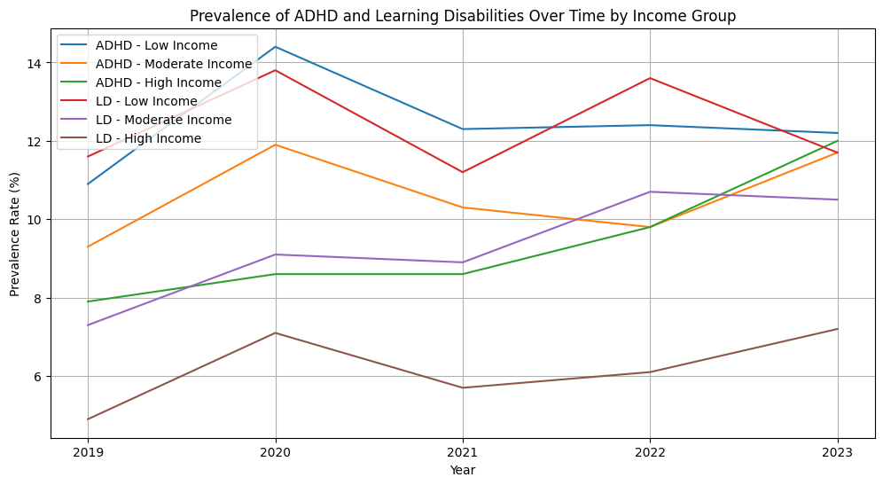

```python
# Combine ADHD and LD poverty data
combined_pov_df = pd.merge(ADHD_pov_df, LD_pov_df, on='Year', suffixes=('_ADHD', '_LD'))

# Line graph: Prevalence over time by income group
plt.figure(figsize=(12, 6))
plt.plot(combined_pov_df['Year'], combined_pov_df['Low Income Group Prevalence_ADHD'], label='ADHD - Low Income')
plt.plot(combined_pov_df['Year'], combined_pov_df['Moderate Income Group Prevalence_ADHD'], label='ADHD - Moderate Income')
plt.plot(combined_pov_df['Year'], combined_pov_df['Higher Income Group Prevalence_ADHD'], label='ADHD - High Income')
plt.plot(combined_pov_df['Year'], combined_pov_df['Low Income Group Prevalence_LD'], label='LD - Low Income')
plt.plot(combined_pov_df['Year'], combined_pov_df['Moderate Income Group Prevalence_LD'], label='LD - Moderate Income')
plt.plot(combined_pov_df['Year'], combined_pov_df['Higher Income Group Prevalence_LD'], label='LD - High Income')
plt.xlabel('Year')
plt.ylabel('Prevalence Rate (%)')
plt.title('Prevalence of ADHD and Learning Disabilities Over Time by Income Group')
plt.legend()
plt.grid(True)
plt.show()
```

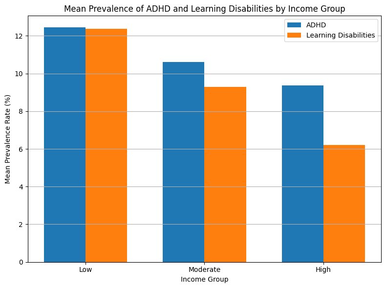

```python
# Merge the ADHD and LD dataframes on 'Year'
combined_pov_df = pd.merge(ADHD_pov_df, LD_pov_df, on='Year', suffixes=('_ADHD', '_LD'))

# Calculate mean prevalence for each income group
adhd_means = [
    combined_pov_df['Low Income Group Prevalence_ADHD'].mean(),
    combined_pov_df['Moderate Income Group Prevalence_ADHD'].mean(),
    combined_pov_df['Higher Income Group Prevalence_ADHD'].mean()
]

ld_means = [
    combined_pov_df['Low Income Group Prevalence_LD'].mean(),
    combined_pov_df['Moderate Income Group Prevalence_LD'].mean(),
    combined_pov_df['Higher Income Group Prevalence_LD'].mean()
]

# Create a new DataFrame for the bar plot
mean_prevalence = pd.DataFrame({
    'Income Group': ['Low', 'Moderate', 'High'],
    'ADHD Prevalence': adhd_means,
    'LD Prevalence': ld_means
})

# Plotting the bar graph
plt.figure(figsize=(8, 6))
bar_width = 0.35
index = np.arange(len(mean_prevalence['Income Group']))

plt.bar(index, mean_prevalence['ADHD Prevalence'], bar_width, label='ADHD')
plt.bar(index + bar_width, mean_prevalence['LD Prevalence'], bar_width, label='Learning Disabilities')

plt.xlabel('Income Group')
plt.ylabel('Mean Prevalence Rate (%)')
plt.title('Mean Prevalence of ADHD and Learning Disabilities by Income Group')
plt.xticks(index + bar_width / 2, mean_prevalence['Income Group'])
plt.legend()
plt.grid(axis='y')
plt.tight_layout()
plt.show()
```

**Analysis**

The data presented in this graph contradicts my initial hypothesis that individuals from higher tax brackets would have higher rates of diagnoses. My graph illustrates changes in ADHD and learning disabilities from 2019 to 2023 across different income groups. Throughout these five years, children from low-income families consistently show the highest rates of both conditions.

### Prevalance Rates per Racial Idenity

To explore how the prevalence of ADHD and Learning Disabilities (LD) varied over time by race, I began by generating two line graphs. These graphs visualized the prevalence rates for each racial group across the years available in the dataset.

For ADHD and LD, I looped through the columns in their respective data frames, selecting only those columns that included "Prevalence" in their names. I plotted these rates against the "Year" column, adding appropriate labels, titles, and a grid to enhance readability.

After visualizing the trends over time, I shifted my focus to the overall mean prevalence by race. I filtered the columns again to isolate only the prevalence rates and computed the mean for each racial group across all years.

To improve the plot's clarity, I removed the " Prevalence" suffix from each column name, retaining only the race labels. Finally, I combined the ADHD and LD averages into a single data frame and displayed them side by side in a grouped bar chart, making it easier to compare the average prevalence rates of ADHD and LD across different racial groups.

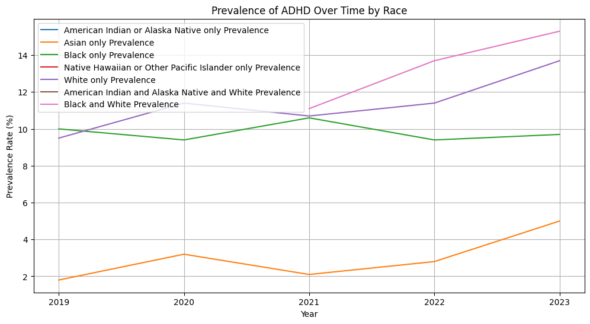

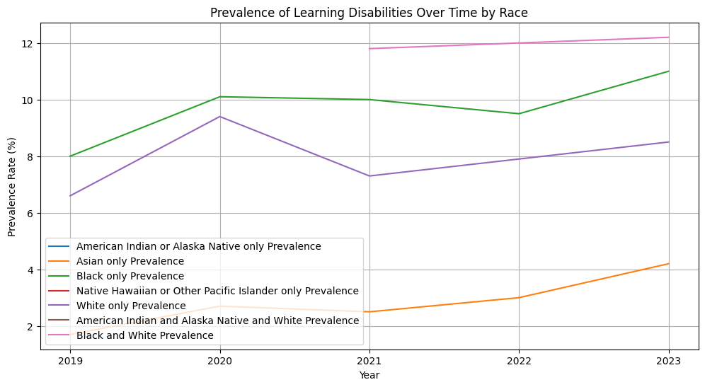

```python
# Line graph: Prevalence over time by race for ADHD
plt.figure(figsize=(12, 6))
for col in ADHD_race_df.columns:
    if 'Prevalence' in col:
        plt.plot(ADHD_race_df['Year'], ADHD_race_df[col], label=col)
plt.xlabel('Year')
plt.ylabel('Prevalence Rate (%)')
plt.title('Prevalence of ADHD Over Time by Race')
plt.legend()
plt.grid(True)
plt.show()

# Line graph: Prevalence over time by race for LD
plt.figure(figsize=(12, 6))
for col in LD_race_df.columns:
    if 'Prevalence' in col:
        plt.plot(LD_race_df['Year'], LD_race_df[col], label=col)
plt.xlabel('Year')
plt.ylabel('Prevalence Rate (%)')
plt.title('Prevalence of Learning Disabilities Over Time by Race')
plt.legend()
plt.grid(True)
plt.show()
```

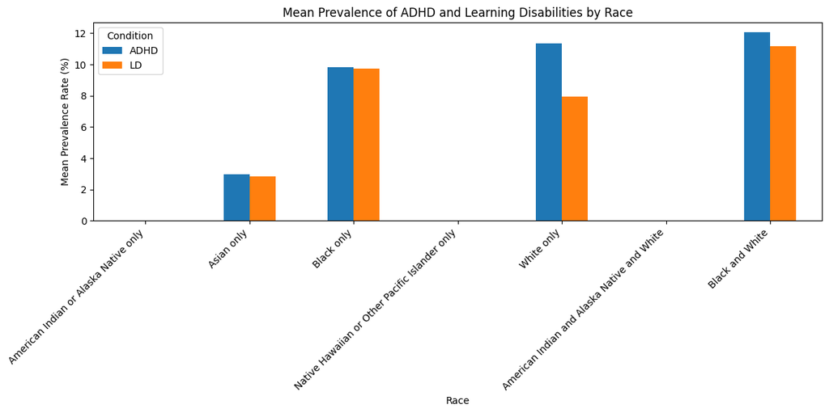

```python
# Calculate means
adhd_means = ADHD_race_df[[col for col in ADHD_race_df.columns if 'Prevalence' in col]].mean()
ld_means = LD_race_df[[col for col in LD_race_df.columns if 'Prevalence' in col]].mean()

# Clean up column names to just race
adhd_means.index = [col.replace(' Prevalence', '') for col in adhd_means.index]
ld_means.index = [col.replace(' Prevalence', '') for col in ld_means.index]

# Combine into a DataFrame
mean_df = pd.DataFrame({'ADHD': adhd_means, 'LD': ld_means})

# Plot
mean_df.plot(kind='bar', figsize=(12, 6))
plt.xlabel('Race')
plt.ylabel('Mean Prevalence Rate (%)')
plt.title('Mean Prevalence of ADHD and Learning Disabilities by Race')
plt.xticks(rotation=45, ha='right')
plt.legend(title='Condition')
plt.tight_layout()
plt.show()
```

**Analysis**

The first graph illustrates the prevalence of ADHD over time, broken down by race. A notable trend is the sharp increase in ADHD diagnoses among individuals identifying as "Black and White," particularly between 2021 and 2023. Similarly, those categorized as "White only" show a steady upward trend. In contrast, the "Black only" group maintains relatively stable rates with only minor fluctuations. The "Asian only" group consistently demonstrates the lowest prevalence, although there is a gradual increase over time. These variations may reflect disparities in access to diagnoses or differing cultural perceptions and stigmas related to mental health.

The second graph presents the prevalence of learning disabilities (LD) over the same time frame and racial categories. Once again, individuals identifying as "Black and White" exhibit the highest and most consistent rates, with a slow but steady increase. The "Black only" and "White only" groups follow similar trends, while the "Asian only" group maintains the lowest prevalence. This pattern closely mirrors the trends seen in ADHD, suggesting that similar factors—such as socioeconomic conditions or inequities in access to special education services—may influence both diagnoses.

### Prevalance Rates per Sex

Below is an exploratory analysis of the prevalence of learning disabilities (LD) and ADHD by sex over time.

First, I visualized the trends in LD prevalence over time using a line graph. I plotted each sex on the same graph to compare their trajectories from year to year. This helped visually identify differences or patterns in prevalence by sex over time.

Next, I shifted the focus to summarizing the data using a bar graph that compares the mean prevalence of LD and ADHD between males and females. To do this, I first created a new data frame where I calculated the average prevalence rates separately for LD and ADHD by sex. This involved taking the mean of the respective prevalence columns from the original datasets.

For the bar plot, I set the x-axis to represent sex and plotted two side-by-side bars for each group—one for LD and one for ADHD—using a defined bar width. This format made it easier to compare the mean prevalence of each condition across sexes. I used tight_layout() to ensure the formatting was clean and nothing overlapped.

This approach allowed me to examine the temporal trends and overall average differences in prevalence rates, offering a complete understanding of how these conditions differ by sex.

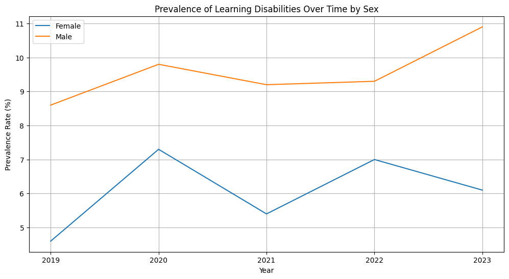

```python
# Line graph: Prevalence over time by sex for LD
plt.figure(figsize=(12, 6))
plt.plot(LD_sex_df['Year'], LD_sex_df['Female Prevalence'], label='Female')
plt.plot(LD_sex_df['Year'], LD_sex_df['Male Prevalence'], label='Male')
plt.xlabel('Year')
plt.ylabel('Prevalence Rate (%)')
plt.title('Prevalence of Learning Disabilities Over Time by Sex')
plt.legend()
plt.grid(True)
plt.show()
```

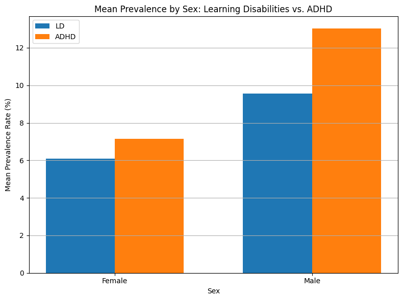

```python
# Bar graph: Mean prevalence by sex for LD and ADHD

# Create DataFrame for mean prevalence
mean_prevalence_df = pd.DataFrame({
    'Sex': ['Female', 'Male'],
    'LD': [
        LD_sex_df['Female Prevalence'].mean(),
        LD_sex_df['Male Prevalence'].mean()
    ],
    'ADHD': [
        ADHD_sex_df['Female Prevalence'].mean(),
        ADHD_sex_df['Male Prevalence'].mean()
    ]
})

# Plotting
x = np.arange(len(mean_prevalence_df['Sex']))  # label locations
width = 0.35  # width of the bars

plt.figure(figsize=(8, 6))
plt.bar(x - width/2, mean_prevalence_df['LD'], width, label='LD')
plt.bar(x + width/2, mean_prevalence_df['ADHD'], width, label='ADHD')

plt.xlabel('Sex')
plt.ylabel('Mean Prevalence Rate (%)')
plt.title('Mean Prevalence by Sex: Learning Disabilities vs. ADHD')
plt.xticks(x, mean_prevalence_df['Sex'])
plt.legend()
plt.grid(axis='y')
plt.tight_layout()
plt.show()
```

**Analysis**

My original hypothesis that men have higher diagnosis rates than women has been strongly validated.

My first graph illustrates the prevalence of learning disabilities from 2019 to 2023, separated by sex. It's noteworthy that, throughout these years, males consistently show a higher prevalence rate than females. There is a significant spike in 2020 for both sexes, with a sharper increase for females, although the rate for males remains higher. By 2023, the prevalence for males will continue to rise, while the female rate will fluctuate but ultimately end up lower than its peak in 2020.

My second graph presents the mean prevalence of learning disabilities (LD) and ADHD among males and females. It indicates that males have significantly higher rates of both LD and ADHD compared to females. The rates of ADHD, in particular, are nearly double for males compared to females.

## Model Questions

Based on the data and exploratory analysis, I identified two key modeling questions that can be addressed using the CDC's NHIS data on ADHD and learning disability diagnoses.

**Research Question 1:** Does socioeconomic status (SES), as measured by poverty level, predict the likelihood of a child being diagnosed with ADHD or a learning disability?

- **Dependent Variable:** Prevalence of ADHD or learning disabilities in the dataset (likely expressed as a percentage or rate).
- **Independent Variables:** Poverty Level Category (Low, Moderate, High Income) and Year.
- **Proposed Methodology:** Linear Regression.

I will build a regression model to examine the relationship between poverty level and ADHD/learning disability diagnosis rates over time. Including the year will help account for any temporal trends, policy changes, or diagnostic criteria. This model assumes a linear relationship and will help determine if lower SES is associated with higher diagnosis rates.

**Research Question 2:** To what extent do race and gender predict disparities in diagnosis rates for ADHD and learning disabilities?

- **Dependent Variable:** Diagnosis of ADHD or a learning disability (binary: diagnosed or not diagnosed). (binary: diagnosed or not diagnosed)
- **Independent Variables:** Race (categorical) and Gender (binary).
- **Proposed Methodology:** Decision Tree Classification Model.

A decision tree model will identify patterns and disparities in diagnosis rates based on race and gender. This method is non-linear and interpretable, allowing for exploring complex interactions among demographic factors.

## Conclusion

Ultimately, the trends in diagnosis rates for ADHD and learning disabilities challenged my initial hypothesis that children from higher-income households would have higher diagnosis rates due to better access to healthcare and early intervention services. I had assumed that more significant financial resources would naturally lead to earlier and more frequent diagnoses.

| Hypothesis | Supported? | Evidence |
| --- | --- | --- |
| White, higher-income kids more likely to be diagnosed | ❌ No | Low-income groups showed higher prevalence overall |
| Boys more likely to be diagnosed than girls | ✅ Yes | Males had consistently higher ADHD & LD prevalence |
| Racial bias may impact diagnosis | ✅ Partial | Black and White multiracial group had highest prevalence |

However, the data revealed a more complex story. Over multiple years, including during the COVID-19 pandemic, children from low-income households consistently exhibited higher prevalence rates for both ADHD and learning disabilities. At first, this finding seemed counterintuitive—if access to services is limited for lower-income families, why are diagnoses more common among them?

While I could not explore every underlying reason within this project's scope, I began to understand that the diagnosis process is not solely about access. Factors such as school environments, teacher referrals, and structural inequities in public education all play important roles. Schools may sometimes be the only places where behavioral challenges are noticed and addressed. Diagnoses might be sought to access special education resources in underfunded districts.

This project changed my understanding of how diagnosis operates within broader systems. It raised important questions about how institutional practices, socioeconomic context, and visibility in the classroom influence who gets diagnosed and why. This notebook provides a small glimpse into these patterns and encourages further inquiry into how factors like school type, geography, and parental education interact with diagnosis rates.